# Supervised Learning - Foundations Project: ReCell

### TEST FOR LINEARITY AND INDEPENDENCE

**Why the test?**

- Linearity describes a straight-line relationship between two variables, predictor variables must have a linear relation with the dependent variable.
- The independence of the error terms (or residuals) is important. If the residuals are not independent, then the confidence intervals of the coefficient estimates will be narrower and make us incorrectly conclude a parameter to be statistically significant.

**How to check linearity and independence?**

- Make a plot of fitted values vs residuals.
- If they don't follow any pattern, then we say the model is linear and residuals are independent.
- Otherwise, the model is showing signs of non-linearity and residuals are not independent.

**How to fix if this assumption is not followed?**

- We can try to transform the variables and make the relationships linear.

```python
# creating a dataframe with actual, fitted and residual values
df_pred = pd.DataFrame()

df_pred["Actual Values"] = y_train  # actual values
df_pred["Fitted Values"] = olsmod2.fittedvalues  # predicted values
df_pred["Residuals"] = olsmod2.resid  # residuals

df_pred.head()
```

|  | Actual Values | Fitted Values | Residuals |
| --- | --- | --- | --- |
| 3026 | 4.087488 | 3.855243 | 0.232245 |
| 1525 | 4.448399 | 4.628813 | -0.180413 |
| 1128 | 4.315353 | 4.280778 | 0.034574 |
| 3003 | 4.282068 | 4.206270 | 0.075798 |
| 2907 | 4.456438 | 4.470315 | -0.013877 |

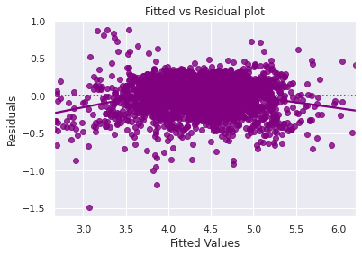

```python
# Plot the fitted values vs residuals to check linearity and independence

sns.residplot(
    data=df_pred, x="Fitted Values", y="Residuals", color="purple", lowess=True
)
plt.xlabel("Fitted Values")
plt.ylabel("Residuals")
plt.title("Fitted vs Residual plot")
plt.show()
```

#### Observation

- The scatter plots shows the distribution between residuals(errors) vs fitted values(predicted values)
- There seems to be no pattern shown in this plot, hence the assumption of linearity and independence are satisfied
- It abviously shows a random plot with no strong pattern

### TEST FOR NORMALITY

Why the test?

Error terms, or residuals, should be normally distributed. If the error terms are not normally distributed, confidence intervals of the coefficient estimates may become too wide or narrow. Once confidence interval becomes unstable, it leads to difficulty in estimating coefficients based on minimization of least squares. Non-normality suggests that there are a few unusual data points that must be studied closely to make a better model. How to check normality?

The shape of the histogram of residuals can give an initial idea about the normality. It can also be checked via a Q-Q plot of residuals. If the residuals follow a normal distribution, they will make a straight line plot, otherwise not. Other tests to check for normality includes the Shapiro-Wilk test. Null hypothesis: Residuals are normally distributed Alternate hypothesis: Residuals are not normally distributed How to fix if this assumption is not followed?

We can apply transformations like log, exponential, arcsinh, etc. as per our data.

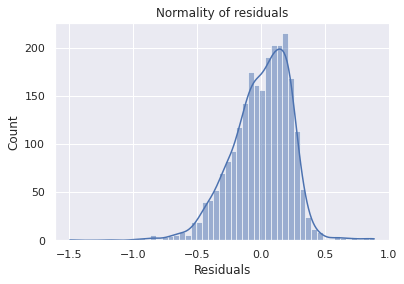

```python
sns.histplot(data=df_pred, x="Residuals", kde=True)
plt.title("Normality of residuals")
plt.show()
```

- The histogram of residuals shows a bell shape with a bit of left skewness

Use another approach by checking for normality using the Q-Q plot.

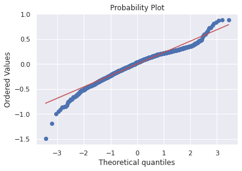

```python
import pylab
import scipy.stats as stats

stats.probplot(df_pred["Residuals"], dist="norm", plot=pylab)
plt.show()
```

- The residuals pretty much follow a straight line except for the tails.

#### Let's check the results of the Shapiro-Wilk test for normality.

```python
stats.shapiro(df_pred["Residuals"])
```

```
(0.9690961837768555, 2.130726936518395e-22)
```

- Since p-value < 0.05, the residuals are not normal as per the Shapiro-Wilk test.
- Strictly speaking, the residuals are not normal.
- However, as an approximation, we can accept this distribution as close to being normal.
- **So, the assumption is satisfied.**

### TEST FOR HOMOSCEDASTICITY

Homoscedascity: If the variance of the residuals is symmetrically distributed across the regression line, then the data is said to be homoscedastic.

Heteroscedascity: If the variance is unequal for the residuals across the regression line, then the data is said to be heteroscedastic.

Why the test?

The presence of non-constant variance in the error terms results in heteroscedasticity. Generally, non-constant variance arises in presence of outliers. How to check for homoscedasticity?

The residual vs fitted values plot can be looked at to check for homoscedasticity. In the case of heteroscedasticity, the residuals can form an arrow shape or any other non-symmetrical shape. The goldfeldquandt test can also be used. If we get a p-value > 0.05 we can say that the residuals are homoscedastic. Otherwise, they are heteroscedastic. Null hypothesis: Residuals are homoscedastic Alternate hypothesis: Residuals have heteroscedasticity How to fix if this assumption is not followed?

Heteroscedasticity can be fixed by adding other important features or making transformations.

```python
import statsmodels.stats.api as sms
from statsmodels.compat import lzip

name = ["F statistic", "p-value"]
test = sms.het_goldfeldquandt(df_pred["Residuals"], X_train3)
lzip(name, test)
```

```
[('F statistic', 1.0438035947010258), ('p-value', 0.22944475832466488)]
```

#### Observations

- Our p-value is 0.22
- Since p-value > 0.05, we conclude that the residuals are homoscedastic. So, we can conclude that the assumption is satisfied

## Predictions on test data

Now that we have checked all the assumptions of linear regression and they are satisfied, let's go ahead with prediction.

```python
# predictions on the test set
pred = olsmod2.predict(X_test3)

df_pred_test = pd.DataFrame({"Actual": y_test, "Predicted": pred})
df_pred_test.sample(10, random_state=1)
```

|  | Actual | Predicted |
| --- | --- | --- |
| 1995 | 4.566741 | 4.373741 |
| 2341 | 3.696103 | 3.962922 |
| 1913 | 3.592093 | 3.690961 |
| 688 | 4.306495 | 4.116687 |
| 650 | 4.522115 | 5.137917 |
| 2291 | 4.259294 | 4.395249 |
| 40 | 4.997685 | 5.434104 |
| 1884 | 3.875359 | 4.054845 |
| 2538 | 4.206631 | 4.047439 |
| 45 | 5.380450 | 5.276715 |

- We can observe here that our model has returned pretty good prediction results, and the actual and predicted values are comparable

## Final Model

Let's recreate the final model and print it's summary to gain insights.

```python
X_train_final = X_train3.copy()
X_test_final = X_test3.copy()
```

```python
olsmodel_final = sm.OLS(y_train, X_train_final).fit()
print(olsmodel_final.summary())
```

```
                              OLS Regression Results
=================================================================================
Dep. Variable:     normalized_used_price   R-squared:                       0.842
Model:                               OLS   Adj. R-squared:                  0.842
Method:                    Least Squares   F-statistic:                     988.1
Date:                   Sun, 05 Jun 2022   Prob (F-statistic):               0.00
Time:                           07:09:02   Log-Likelihood:                 104.71
No. Observations:                   2417   AIC:                            -181.4
Df Residuals:                       2403   BIC:                            -100.4
Df Model:                             13
Covariance Type:               nonrobust
========================================================================================
                           coef    std err          t      P>|t|      [0.025      0.975]
----------------------------------------------------------------------------------------
const                    1.3777      0.051     26.879      0.000       1.277       1.478
screen_size              0.0256      0.003      7.764      0.000       0.019       0.032
main_camera_mp           0.0212      0.001     15.313      0.000       0.018       0.024
selfie_camera_mp         0.0140      0.001     13.203      0.000       0.012       0.016
ram                      0.0175      0.004      3.950      0.000       0.009       0.026
battery              -1.507e-05    7.1e-06     -2.122      0.034    -2.9e-05   -1.14e-06
weight                   0.0009      0.000      7.177      0.000       0.001       0.001
normalized_new_price     0.4222      0.011     39.125      0.000       0.401       0.443
years_since_released    -0.0199      0.004     -5.516      0.000      -0.027      -0.013
brand_name_Lenovo        0.0492      0.021      2.288      0.022       0.007       0.091
brand_name_Nokia         0.0675      0.031      2.203      0.028       0.007       0.128
brand_name_Xiaomi        0.0893      0.026      3.498      0.000       0.039       0.139
os_Others               -0.0704      0.030     -2.356      0.019      -0.129      -0.012
4g_yes                   0.0499      0.015      3.357      0.001       0.021       0.079
==============================================================================
Omnibus:                      232.847   Durbin-Watson:                   1.913
Prob(Omnibus):                  0.000   Jarque-Bera (JB):              458.097
Skew:                          -0.628   Prob(JB):                    3.35e-100
Kurtosis:                       4.724   Cond. No.                     3.85e+04
==============================================================================

Warnings:
[1] Standard Errors assume that the covariance matrix of the errors is correctly specified.
[2] The condition number is large, 3.85e+04. This might indicate that there are
strong multicollinearity or other numerical problems.
```

```python
# checking model performance on train set (seen 70% data)
print("Training Performance\n")
olsmodel_final_train_perf = model_performance_regression(
    olsmodel_final, X_train_final, y_train
)
olsmodel_final_train_perf
```

```
Training Performance
```

|  | RMSE | MAE | R-squared | Adj. R-squared | MAPE |
| --- | --- | --- | --- | --- | --- |
| 0 | 0.231712 | 0.181763 | 0.842409 | 0.841491 | 4.359962 |

```python
# checking model performance on test set (seen 30% data)
print("Test Performance\n")
olsmodel_final_test_perf = model_performance_regression(
    olsmodel_final, X_test_final, y_test
)
olsmodel_final_test_perf
```

```
Test Performance
```

|  | RMSE | MAE | R-squared | Adj. R-squared | MAPE |
| --- | --- | --- | --- | --- | --- |
| 0 | 0.236807 | 0.18348 | 0.844523 | 0.842393 | 4.467055 |

- The model is able to explain ~84.2% of the variation in the data
- The train and test RMSE and MAE are low and comparable. So, our model is not suffering from overfitting